# Data-analytiikka - Harjoitus 8

Huomaa, että tehtävät tulee palauttaa html-tiedostona, jossa näkyvät sekä koodisolujen sisällöt että tulosteet. Notebookin saat html-tiedostoksi valitsemalla File -> Download as -> HTML. Tehtävien vastaukset voi tehdä yhteen tai useampaan koodisoluun.

**Opiskelijan nimi**: Eino Puttonen

**Opiskelijanumero**: AB7200

## Kuvaajien muotoilut

Alla on annettu kaavion luontikoodi (käyttäen np-taulukoita). Tee kaaviosta yksityiskohtaisesti alla olevan mallin mukainen. Tutki [matplotlibin speksistä](https://matplotlib.org/3.5.3/api/_as_gen/matplotlib.pyplot.html), miten kaavion osia muotoillaan. Akseleiden ja kuvaajan muiden viivojen paksuudet voit jättää oletusasetuksille.

[figure not shown]

Pisteytys: 1.5 p

```python
import numpy as np
import pandas as pd
import matplotlib.pyplot as plt
import seaborn as sns
from matplotlib.ticker import MultipleLocator
from matplotlib.ticker import AutoMinorLocator, FixedLocator
```

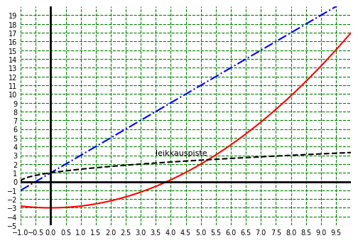

```python
x = np.linspace(-1,10,1000)
y1 =  2*x +1
y2 = 0.2*x**2-3
y3 = (x+1)**0.5


fig, ax = plt.subplots(figsize=(6, 4))
plt.plot(x, y1, linestyle='dashdot', color='blue')
plt.plot(x, y2, color='red')
plt.plot(x, y3, linestyle='--', color='black')
#gridi näkyviin
ax.grid(axis='both', linestyle='--')

#y akselin pienin ja suurin arvo yhden välein
plt.yticks(np.arange(-5, 20, 1))
plt.xticks(np.arange(-1,10,.5))
#paksut viivat 0-tasoon
plt.axhline(0, color='black', linewidth=2)
plt.axvline(0, color='black', linewidth=2)
#gridin viivatyyli ja väri
ax.grid(which = "minor", linestyle='--')
plt.grid(color='green')
#fontin koko
plt.tick_params(axis='both', which='both', labelsize=7, length=0)

plt.xlim(-1, 10)
plt.ylim(-5,20)
#poistetaan reunat
[ax.spines[side].set_visible(False) for side in ax.spines]
#
#plt.gca().xaxis.set_major_locator(MultipleLocator(0.5))
#plt.gca().yaxis.set_major_locator(MultipleLocator(1))
#teksti kuvan
plt.text(3.5, 3, "leikkauspiste", fontsize=8)
plt.show()
```

## Subplots

Lue datasetti 'cybersecyrity_attacks.csv' DataFrameen urlista https://student.labranet.jamk.fi/~ajota/Datasets/cybersecurity_attacks.csv.

Tee seuraavat kaaviot samaan kuvaan vierekkäin, mallin näet alla.

1. Visualisoi piirakkakaavioon eri hyökkäystyyppien prosentuaaliset osuudet datasetissä.
2. Visualisoi pylväskaavioon hyökkäystyypin 'Malware' lukumäärät kuukausittain vuonna 2022. (Vinkki: Tee ensin "Timestamp"-sarakkeesta uudet sarakkeet "Year" ja "Month" ja lähde suodattamaan ja ryhmittelemään dataa näiden avulla.

[figure not shown]

```python
# Vastaus
url = "https://student.labranet.jamk.fi/~ajota/Datasets/cybersecurity_attacks.csv"
df = pd.read_csv(url)
#df
```

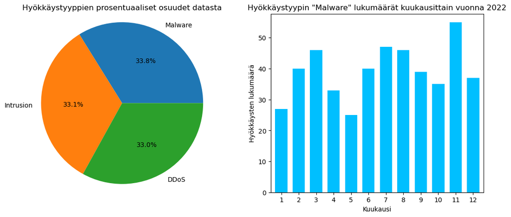

```python
#Timestamp-sarakkeesta vuosi ja kuukausi
df['Timestamp'] = pd.to_datetime(df['Timestamp'])
df['Year'] = df['Timestamp'].dt.year
df['Month'] = df['Timestamp'].dt.month
#tehdään yksi kuva missä on kaksi subplotia
plt.figure(figsize=(13, 5))
#määritetään rivien ja sarakkaiden määrä, lopuksi määritetään ensimmäin subplot
plt.subplot(1, 2, 1)
# Piirakkakaavio hyökkäystyyppien prosentuaalisista osuuksista
attack_type_counts = df['Attack Type'].value_counts()
plt.pie(attack_type_counts, labels=attack_type_counts.index, autopct='%1.1f%%')
plt.title('Hyökkäystyyppien prosentuaaliset osuudet datasta')
plt.axis('equal')
# Pylväskaavio
plt.subplot(1, 2, 2)
malware_attacks_2022 = df[(df['Attack Type'] == 'Malware') & (df['Year'] == 2022)]
monthly_malware_counts = malware_attacks_2022.groupby('Month').size()
monthly_malware_counts.plot(kind='bar', color='deepskyblue', width=0.7
                           )
plt.title('Hyökkäystyypin "Malware" lukumäärät kuukausittain vuonna 2022')
plt.xlabel('Kuukausi')
plt.ylabel('Hyökkäysten lukumäärä')
plt.xticks(rotation=0)



plt.show()
```

## Liikennetietoja

Tiedostossa https://student.labranet.jamk.fi/~ajota/Datasets/lam.csv on yhden päivän tietoja eräältä automaattiselta liikennemittausasemalta ([LAM](https://vayla.fi/avoindata/tietoaineistot/lam-tiedot)). Erotin on puolipiste.

Lue tiedot DataFrameen ja esitä visualisoimalla seuraavat asiat ajansuhteen tunneittain, (scatter ja plot) kuten alla olevassa mallissa

- ajoneuvojen nopeus ajoneuvoluokittain (scatter)
- ajoneuvojen määrä ajoneuvoluokittain (plot)

Vinkki: Voit käyttää for-looppia eri ajoneuvoluokkien lukumäärien visualisoinnissa.

[figure not shown]

```python
# Vastaus

df = pd.read_csv('https://student.labranet.jamk.fi/~ajota/Datasets/lam.csv', sep=';')
df
```

|  | tunti | min | sek | suunta | ajoneuvoluokka | nopeus |
| --- | --- | --- | --- | --- | --- | --- |
| 0 | 0 | 1 | 56 | 1 | 1 | 105 |
| 1 | 0 | 4 | 43 | 2 | 1 | 87 |
| 2 | 0 | 5 | 55 | 1 | 1 | 70 |
| 3 | 0 | 5 | 58 | 1 | 1 | 79 |
| 4 | 0 | 6 | 9 | 2 | 1 | 86 |
| ... | ... | ... | ... | ... | ... | ... |
| 9545 | 23 | 58 | 0 | 2 | 1 | 98 |
| 9546 | 23 | 58 | 58 | 2 | 1 | 114 |
| 9547 | 23 | 59 | 22 | 2 | 1 | 117 |
| 9548 | 23 | 59 | 26 | 2 | 1 | 104 |
| 9549 | 23 | 59 | 28 | 1 | 1 | 93 |

9550 rows × 6 columns

[output not shown]